# Categories, tables, and grouping

# Part III: Grouping

1. **Identify the grouping variable:** which categories am I comparing?
2. **Select the numerical variable:** what am I summarising?
3. **Choose a calculation:** count, sum, mean or median.
4. **Read the result:** one summary per group, and explain what each number means.

## Our grouping question: where do hires start, and how long do they last?

Return to `trips`: **one record is one hire**, with a starting borough and a recorded duration in minutes.

```python
trips[["start_borough", "end_borough", "day_type", "duration_min"]].head(3)
```

|  | start_borough | end_borough | day_type | duration_min |
| --- | --- | --- | --- | --- |
| 0 | Lambeth | Lambeth | Weekday | 5.5 |
| 1 | Hackney | Hackney | Weekday | 12.4 |
| 2 | City of London | Islington | Weekday | 8.6 |

| Decision | Our choice |
| --- | --- |
| Grouping variable | `start_borough` |
| Numerical variable | `duration_min` |
| Calculations | Count hires; compare mean and median duration |

The result is one summary of `duration_min` per `start_borough`.

## Step 1: group hires by starting borough

Put hires with the same `start_borough` together, then count them.

```python
# Create the "groupby" obeject
borough_groups = trips.groupby("start_borough")

# Print the size of each category
print(borough_groups.size())
```

```
start_borough
Camden                     39135
City of London             28988
Hackney                    20434
Hammersmith and Fulham     24390
Islington                  18256
Kensington and Chelsea     44598
Lambeth                    32875
Newham                      4400
Southwark                  32810
Tower Hamlets              60677
Wandsworth                 25706
Westminster               111270
dtype: int64
```

`groupby("start_borough")` defines the groups. `.size()` counts all records in each group.

## Steps 2 and 3: select duration and calculate its median

**Question:** What is the median recorded hire duration for each starting borough?

```python
# Now we can use .median() to calculate the median duration time.
median_duration = borough_groups["duration_min"].median()
print(median_duration)
```

```
start_borough
Camden                    13.4
City of London            13.1
Hackney                   12.3
Hammersmith and Fulham    12.7
Islington                 11.8
Kensington and Chelsea    14.3
Lambeth                   13.0
Newham                    24.0
Southwark                 13.4
Tower Hamlets             12.3
Wandsworth                14.1
Westminster               16.6
Name: duration_min, dtype: float64
```

`["duration_min"]` selects the column to summarise. `.median()` finds its *middle* value **within each group**.

For hires starting in Westminster, the median is **16.6 minutes**; for Tower Hamlets, **12.3 minutes**, for Newham is **24 minutes**

## EDA normally reveals awkward values

**Exploratory data analysis** (EDA) includes checking the data beind the measurements we want to summarise.

```python
# Use .describe to get an overview of the data distribution for trip durations
print(trips["duration_min"].describe().round(1))
```

```
count    443539.0
mean         23.0
std         231.3
min           0.0
25%           8.1
50%          14.0
75%          23.0
max       75882.8
Name: duration_min, dtype: float64
```

Anything odd here?

## EDA normally reveals awkward values II

**Exploratory data analysis** (EDA) includes checking the data beind the measurements we want to summarise.

```python
# There are clear instances of trips of
# zero length and longer than 24 hours.
print("Zero durations:",
    (trips["duration_min"] == 0).sum())
print("Over 24 hours:",
    (trips["duration_min"] > 1440).sum())
```

```
Zero durations: 199
Over 24 hours: 269
```

There are **199 zero durations** and **269 over 24 hours**. The largest is about **53 days**!

These are values to investigate. **Check the source and document decisions before changing them.**

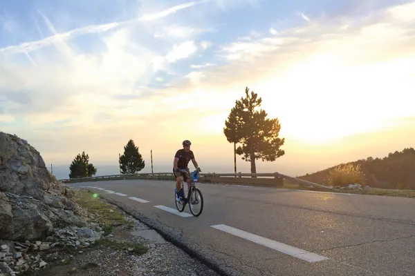

Boris bike on Mont Ventoux

[“On October 26 2013, three friends took on Mont Ventoux on a Boris bike”](https://www.cyclingweekly.com/news/boris-bike-24-hours-challenge-18906)

## Compare count, mean, and median in one table

Apply several calculations to the **same duration values within each borough**.

```python
duration_summary = borough_groups["duration_min"].agg(["count", "sum", "mean", "median"])
duration_summary.round(1)
```

| start_borough | count | sum | mean | median |
| --- | --- | --- | --- | --- |
| Camden | 39135 | 834821.8 | 21.3 | 13.4 |
| City of London | 28988 | 521856.0 | 18.0 | 13.1 |
| Hackney | 20434 | 415807.1 | 20.3 | 12.3 |
| Hammersmith and Fulham | 24390 | 516841.4 | 21.2 | 12.7 |
| Islington | 18256 | 297992.1 | 16.3 | 11.8 |
| Kensington and Chelsea | 44598 | 1116005.5 | 25.0 | 14.3 |
| Lambeth | 32875 | 664102.0 | 20.2 | 13.0 |
| Newham | 4400 | 183944.9 | 41.8 | 24.0 |
| Southwark | 32810 | 702487.5 | 21.4 | 13.4 |
| Tower Hamlets | 60677 | 1308398.3 | 21.6 | 12.3 |
| Wandsworth | 25706 | 613351.9 | 23.9 | 14.1 |
| Westminster | 111270 | 3011087.5 | 27.1 | 16.6 |

`.agg(["count", "mean", "median"])` applies each named calculation. `count` counts non-missing durations; `mean` and `median` are in minutes.

## Reuse the time category: compare hire durations

**Question:** Do recorded hire durations differ between weekday and weekend starts?

Change the **grouping column**; keep the numerical variable and calculations the same.

```python
day_type_summary = trips.groupby("day_type")["duration_min"].agg(["count", "mean", "median"])
day_type_summary.round(1)
```

| day_type | count | mean | median |
| --- | --- | --- | --- |
| Weekday | 358643 | 22.1 | 13.7 |
| Weekend | 84896 | 26.8 | 15.2 |

The median is **13.7 minutes for weekday hires** and **15.2 minutes for weekend hires** in this extract.

`groupby("day_type")` uses the category we created in Part I. These are **unfiltered recorded durations**, not a measure of speed or trip purpose.

## Step 4: say what the result means

Notes:

- The unit of anlaysis is a **hired trip**, not a distinct rider.
- The groups describe **starting locations**, not riders’ home boroughs.
- Recorded duration does not establish **distance, speed, or trip purpose**.

State the measure, the groups and the period. Use the EDA checks to explain the limits of the claim.

## Group by two variables: starting and ending borough

**Question:** Which borough-to-borough pairs appear most often in the hire records?

```python
borough_flows = trips.groupby(["start_borough", "end_borough"]).size()
print(borough_flows.sort_values(ascending=False))
```

```
start_borough           end_borough
Westminster             Westminster               55685
Tower Hamlets           Tower Hamlets             35869
Kensington and Chelsea  Kensington and Chelsea    17531
                        Westminster               13846
Westminster             Kensington and Chelsea    13563
                                                  ...
Kensington and Chelsea  Newham                        7
Newham                  Wandsworth                    7
Wandsworth              Newham                        4
Hammersmith and Fulham  Newham                        3
Newham                  Hammersmith and Fulham        1
Length: 144, dtype: int64
```

`groupby(["start_borough", "end_borough"])` uses **both categories**. Each result counts hires with that combination of endpoints.

## Useful operations on a GroupBy object

We already have `borough_groups = trips.groupby("start_borough")`. Choose an operation to answer your question.

**Counts and categories**

| Method / attribute | What it gives |
| --- | --- |
| `.size()` | Number of records, including those with missing measurements |
| `.count()` | Number of non-missing values in each selected column |
| `.nunique()` | Number of distinct non-missing values |
| `.value_counts()` | Frequency of each label in a selected column |
| `.ngroups` | Number of groups in the GroupBy object; no parentheses |

**Numerical summaries**

| Method | What it gives within each group |
| --- | --- |
| `.sum()` | Total of the selected values |
| `.mean()`, `.median()` | Average or middle value |
| `.min()`, `.max()` | Smallest or largest value |
| `.describe()` | Several summary statistics |
| `.agg([...])` | The calculations you list, such as count, sum, mean and median |

Select the column you want to summarise: `borough_groups["duration_min"].mean()` or `borough_groups["end_station"].nunique()`.

## Later questions: movement and cultural places

We’ve got quite a lot of data now. Let’s spend some time thinking about what types of questions we might be able to ask and answer with it.

## Where this is going

| Question | Table method | A later visual form |
| --- | --- | --- |
| How many records have each label? | `value_counts()` | Bar plot |
| How do type and borough occur together? | `pd.crosstab()` | Grouped or proportional bar plot |
| How does a number vary by category? | `groupby().agg()` | Comparison of group summaries |
| How is one number distributed? | `describe()` | Histogram |

The next lecture turns tables into charts. Categories, counting units, and denominators still determine what the chart can say.

# Part IV: Live coding and exercises

## Exercise 1: categories

Using the venue records already loaded as `venues`:

1. Identify `venue_type` and `borough_name` as nominal variables.
2. Convert venue type to `category` and inspect its possible labels.
3. Filter to Havering. Compare possible labels with observed types.
4. Remove unused labels. Check what changed and what stayed the same.
5. Give one sentence explaining why a proposed split or merge of types would affect a count.
6. Switch to `trips`: create the nominal weekday/weekend category using its `weekday` column.

## Exercise 1 continued: entries and places

**How many records? How many places can we identify?**

1. Check missing `uprn` values: count them and calculate their percentage.
2. Compare `len(venues)` with `venues["uprn"].nunique()`. Remember that `nunique()` excludes blanks.
3. Inspect `venues["uprn"].value_counts().head(10)` for placeholders and scientific notation.
4. Revisit the 100 Club’s records, names and property number.
5. Write one sentence explaining why neither count establishes the number of operating venues.

A UPRN identifies an addressable location. Several organisations can share a property.

## Exercise 2: tables

1. Count venue-type labels and identify the mode.
2. Express those counts as percentages and state what the denominator includes.
3. Make a full borough-by-type crosstab, then display a few rows and columns.
4. Add totals, remembering that hidden types and boroughs still contribute.
5. Compare Camden’s row and column music percentages. Complete one sentence for each question.
6. Use `reset_index()` to make borough an ordinary column.

## Exercise 3: grouping bike hires

Use `trips`, the bike-hire data introduced in Part I.

1. Group hires by `start_borough` and count them with `.size()`.
2. Select `duration_min` and find the median within each group.
3. Inspect the durations and identify one unusual value to investigate.
4. Use `.agg(["count", "mean", "median"])` to compare the summaries.
5. Repeat the duration summary using `day_type` as the grouping column.
6. Write one comparison sentence, naming the measure, groups and period.

**Extra practice:** count starting/ending borough pairs. Which different-borough pair has the most hires?

## Activity: work with your data

If you have time, use your project dataset:

- Choose one categorical column and inspect its definition and missing values.
- Make one frequency table, crosstab or grouped summary relevant to your question.
- State the counting unit and, if using a percentage, the denominator.
- Write one sentence about what the result shows and one thing it cannot establish.

Who created the category, and how does its definition affect this result?